# lecture14_practice_solutions

Run the cell below:

```python
import pandas as pd
import yfinance as yf
```

Use the `yfinance` package to download monthly prices for TSLA, AAPL, and NFLX from 2011 to 2020 (inclusive). Store these data in a dataframe called `raw`.

```python
raw = yf.download(['TSLA','AAPL','NFLX'], interval = '1mo',
                  start = '2011-01-01', end = '2020-12-31')
raw
```

```
[*********************100%***********************]  3 of 3 completed
```

| Date | Adj Close AAPL | Adj Close NFLX | Adj Close TSLA | Close AAPL | Close NFLX | Close TSLA | High AAPL | High NFLX | High TSLA | Low AAPL | Low NFLX | Low TSLA | Open AAPL | Open NFLX | Open TSLA | Volume AAPL | Volume NFLX | Volume TSLA |
| --- | --- | --- | --- | --- | --- | --- | --- | --- | --- | --- | --- | --- | --- | --- | --- | --- | --- | --- |
| 2011-01-01 | 10.376816 | 30.582857 | 4.820000 | 12.118571 | 30.582857 | 4.820000 | 12.450000 | 31.142857 | 5.742000 | 11.601429 | 24.785713 | 4.474000 | 11.630000 | 25.000000 | 5.368000 | 1.084154e+10 | 761392100.0 | 1.421005e+08 |
| 2011-02-01 | 10.801595 | 29.524286 | 4.778000 | 12.614643 | 29.524286 | 4.778000 | 13.032143 | 35.364285 | 5.098000 | 12.061429 | 29.000000 | 4.222000 | 12.189286 | 30.661428 | 4.862000 | 9.295950e+09 | 736982400.0 | 1.465175e+08 |
| 2011-03-01 | 10.657866 | 33.968571 | 5.550000 | 12.446786 | 33.968571 | 5.550000 | 12.916786 | 34.595715 | 5.742000 | 11.652143 | 26.984285 | 4.354000 | 12.695357 | 29.457144 | 4.810000 | 1.130646e+10 | 988351700.0 | 1.628165e+08 |
| 2011-04-01 | 10.707403 | 33.238571 | 5.520000 | 12.504643 | 33.238571 | 5.520000 | 12.683214 | 36.425713 | 5.636000 | 11.434286 | 32.058571 | 4.840000 | 12.539643 | 34.428570 | 5.490000 | 9.253829e+09 | 783979700.0 | 1.494745e+08 |
| 2011-05-01 | 10.637067 | 38.685715 | 6.028000 | 12.422500 | 38.685715 | 6.028000 | 12.565357 | 38.685715 | 6.056000 | 11.765000 | 32.185715 | 5.104000 | 12.490714 | 34.031429 | 5.520000 | 6.912060e+09 | 678188000.0 | 1.517440e+08 |
| ... | ... | ... | ... | ... | ... | ... | ... | ... | ... | ... | ... | ... | ... | ... | ... | ... | ... | ... |
| 2020-09-01 | 114.755981 | 500.029999 | 429.010010 | 115.809998 | 500.029999 | 429.010010 | 137.979996 | 557.390015 | 502.489990 | 103.099998 | 458.600006 | 329.880005 | 132.759995 | 532.599976 | 502.140015 | 3.885245e+09 | 118796900.0 | 1.736285e+09 |
| 2020-10-01 | 107.869240 | 475.739990 | 388.040009 | 108.860001 | 475.739990 | 388.040009 | 125.389999 | 572.489990 | 465.899994 | 107.720001 | 472.209991 | 379.109985 | 117.639999 | 506.029999 | 440.760010 | 2.894666e+09 | 154302400.0 | 8.336664e+08 |
| 2020-11-01 | 117.966499 | 490.700012 | 567.599976 | 119.050003 | 490.700012 | 567.599976 | 121.989998 | 518.729980 | 607.799988 | 107.320000 | 463.410004 | 392.299988 | 109.110001 | 478.869995 | 394.000000 | 2.123077e+09 | 91788900.0 | 7.825988e+08 |
| 2020-11-06 | NaN | NaN | NaN | NaN | NaN | NaN | NaN | NaN | NaN | NaN | NaN | NaN | NaN | NaN | NaN | NaN | NaN | NaN |
| 2020-12-01 | 131.709198 | 540.729980 | 705.669983 | 132.690002 | 540.729980 | 705.669983 | 138.789993 | 545.500000 | 718.719971 | 120.010002 | 491.290009 | 541.210022 | 121.010002 | 492.339996 | 597.590027 | 2.322190e+09 | 77564100.0 | 1.196346e+09 |

157 rows × 18 columns

Use the `raw` data to calculate monthly returns for the 3 firms, as percentage changes in adjusted-close prices. Store these returns in a dataframe called `ret`. Make sure you use `.dropna()` to drop all rows with any missing values before you calculate these returns.

```python
ret = raw['Adj Close'].dropna().pct_change()
ret
```

| Date | AAPL | NFLX | TSLA |
| --- | --- | --- | --- |
| 2011-01-01 | NaN | NaN | NaN |
| 2011-02-01 | 0.040935 | -0.034613 | -0.008714 |
| 2011-03-01 | -0.013306 | 0.150530 | 0.161574 |
| 2011-04-01 | 0.004648 | -0.021490 | -0.005405 |
| 2011-05-01 | -0.006569 | 0.163880 | 0.092029 |
| ... | ... | ... | ... |
| 2020-08-01 | 0.214380 | 0.083211 | 0.741452 |
| 2020-09-01 | -0.100908 | -0.055763 | -0.139087 |
| 2020-10-01 | -0.060012 | -0.048577 | -0.095499 |
| 2020-11-01 | 0.093606 | 0.031446 | 0.462736 |
| 2020-12-01 | 0.116497 | 0.101956 | 0.243252 |

120 rows × 3 columns

Plot the returns of each individual firm, as a separate subplot of a single figure. Make the size of the figure 8 (width) by 6 (hight), and call the title of the figure "Firm Returns".

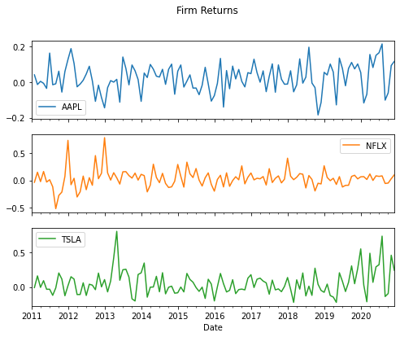

```python
ret.plot(subplots = True, figsize = (8,6), title = "Firm Returns");
```

Print out a table that contains just the mean and standard deviation of returns for each of the 3 firms.

```python
ret.agg(['mean','std'])
```

|  | AAPL | NFLX | TSLA |
| --- | --- | --- | --- |
| mean | 0.024664 | 0.037195 | 0.056422 |
| std | 0.079289 | 0.166394 | 0.179973 |

Print out the covariance matrix for the returns of the 3 firms.

```python
ret.cov()
```

|  | AAPL | NFLX | TSLA |
| --- | --- | --- | --- |
| AAPL | 0.006287 | 0.001299 | 0.004503 |
| NFLX | 0.001299 | 0.027687 | 0.005109 |
| TSLA | 0.004503 | 0.005109 | 0.032390 |

Print out the covariance between the returns of TSLA and AAPL. This should be just a number, not the whole covariance matrix.

```python
covmat = ret[['TSLA','AAPL']].cov()
covmat.loc['AAPL','TSLA']
```

```
0.004503288972464952
```

Print the 12-month autocorrelation in TSLA returns.

```python
ret['TSLA'].autocorr(12)
```

```
-0.10391232198236135
```

Print the 12-month autocorrelation in NFLX returns. Note the difference in signs between TSLA and NFLX. Think about what that tells us about using past performance to forecast future performance for the two stocks.

```python
ret['NFLX'].autocorr(12)
```

```
0.15811392475155542
```

Plot the moving standard deviation in returns for all 3 firms in the same plot (no subplots). Use a fixed 36-month window.

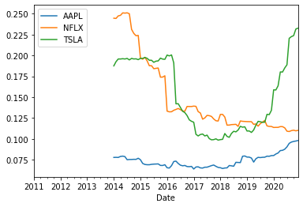

```python
ret.rolling(36).std().plot();
```